# Tomst data script

Vincyane Badouard

2024-05-31

Script to process the T° and moisture data of the Tomst sensors network deployed at Paracou and Nouragues research station.

Problematic: Are air temperature and soil moisture linked to canopy openness and topography?

Localisation des capteurs : transects couvrant les gradients : - topographiques (Paracou : 22, Nouragues : 10) - et d’ouverture de la canopée forestière (10 sur chaque site)

Distance entre les capteurs : 10 m Distance au capteur HOBO : minimum 1 m (pour ne pas subir la perturbation du sol qu’engendre les piquets des HOBO)

Study duration : from 04/01/2023 00:00:00 to 03/31/2024 24:00:00 (1 year)

Sensor info:

Site internet : https://tomst.com/web/en/systems/tms/tms-4/  
Nom : Tomst TMS-4  
3 capteurs de température :

- 8 cm sous le sol
- en surface
- 15 cm au-dessus du sol (air)

1 capteur d’humidité (14 cm sous le sol) -> indirect electrical measurement of the soil moisture (scaled TDT signal)

Résolution temporelle des mesures : de 15 mn Protection contre la lumière directe et la pluie intégrée (shield)

“When exposed to solar radiation, the temperature of an unshielded thermometer will be influenced by these radiative fluxes” (Maclean et al., 2021; Bramer et al., 2018).

“TMS4 dataloggers systematically overestimated temperatures in sunny conditions, though errors were larger for unshielded dataloggers” (Maclean et al., 2021).

Study evaluating the ability of the Tomst TMS4 to measure air T°: Maclean et al., 2021

# *Packages*

# *Read*

## Flux tower data

**2023-204 metadata**:

- Date, Year, Month, Code Day, heure+min, Time, TimeB
- Pluie : Rainfall (mm)
- Temp(55) : Air Temp at 55m high (°C)
- Hr(55) : Air humidity at 55 m high (%)
- Temp(2,0) : Air Temp at 2m high (°C)
- Hr(2,0) : Air humidity at 2 m high (%)
- Tsoil : mean Soil temperature (°C) à différentes profondeurs, issues du capteur CS650. “T_AVG_10cm” “T_AVG_20cm” “T_AVG_80cm” “T_AVG_140cm” “T_AVG_190cm”
- VWC : mean Soil water content (m3 m-3) (Les données VWC sont des données de SWC issues d’une fosse récente, avec des capteurs CS650) (La fosse est à proximité de la Tour, sous couvert) “VWC_AVG_10cm” “VWC_AVG_20cm” “VWC_AVG_80cm” “VWC_AVG_140cm” “VWC_AVG_190cm”

Definition of dry season per month: < 100 mm per month (Bonal et al. 2008)

```
##  [1] "Date"           "Year"           "Month"          "Code"
##  [5] "Day"            "heure+min"      "Time"           "TimeB"
##  [9] "Temp(55)"       "Hr(55)"         "Temp(2,0)"      "Hr(2,0)"
## [13] "Rg"             "CS616"          "Dir vent"       "Vit vent"
## [17] "Pluie"          "Rnet_2"         "CNR4_SW_up_Avg" "CNR4_Rn_Avg"
## [21] "T_AVG_10cm"     "T_AVG_20cm"     "T_AVG_80cm"     "T_AVG_140cm"
## [25] "T_AVG_190cm"    "VWC_AVG_10cm"   "VWC_AVG_20cm"   "VWC_AVG_80cm"
## [29] "VWC_AVG_140cm"  "VWC_AVG_190cm"
```

### Plots

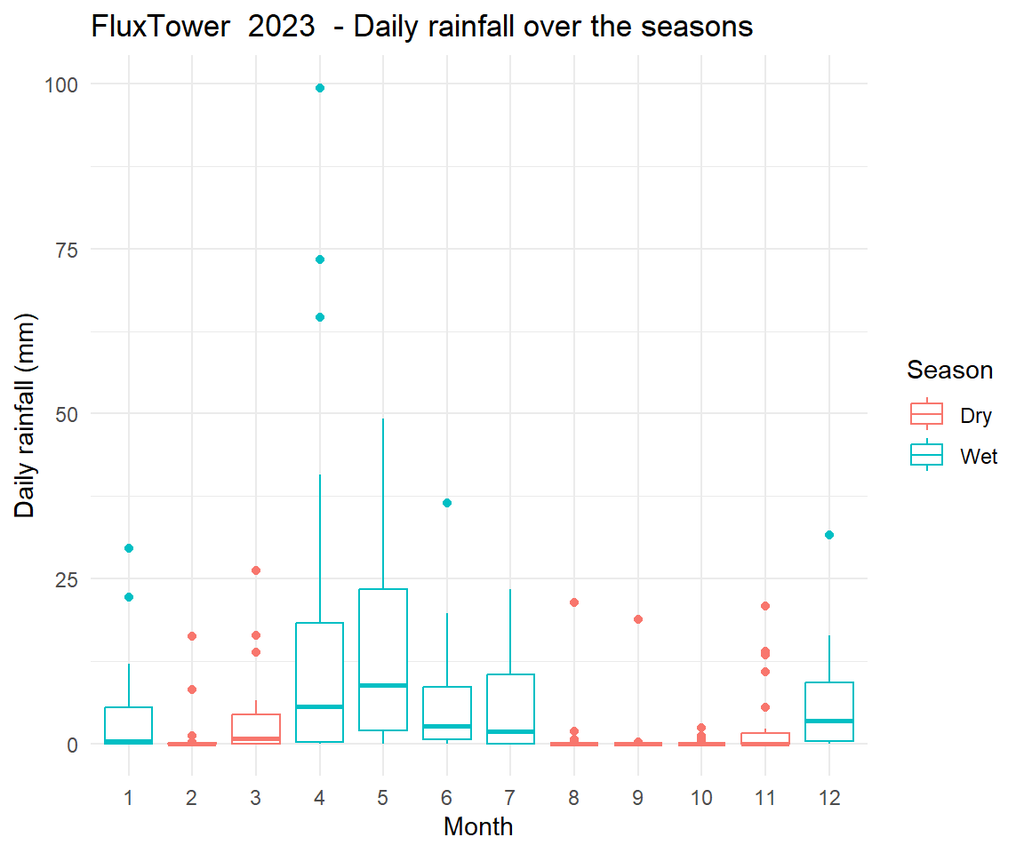

[figure not shown]

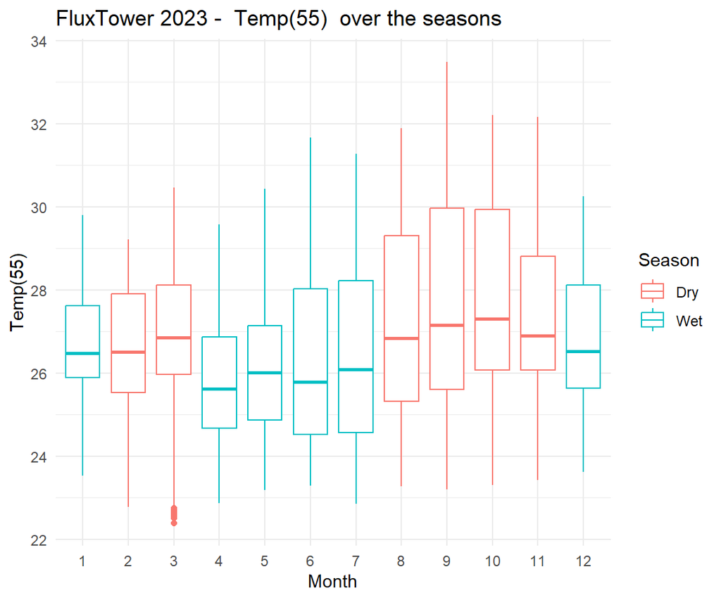

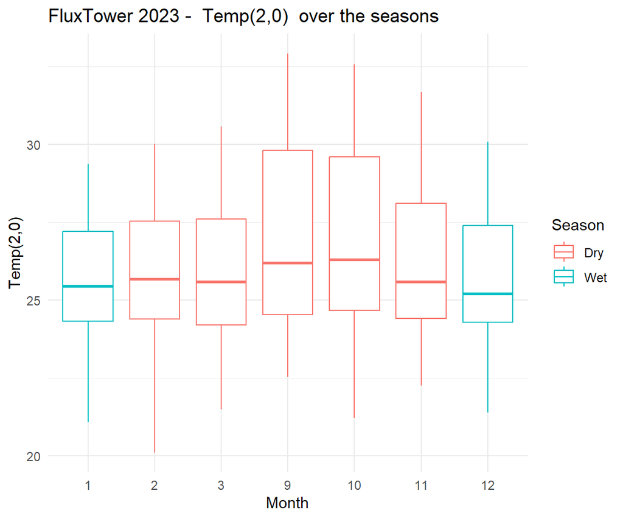

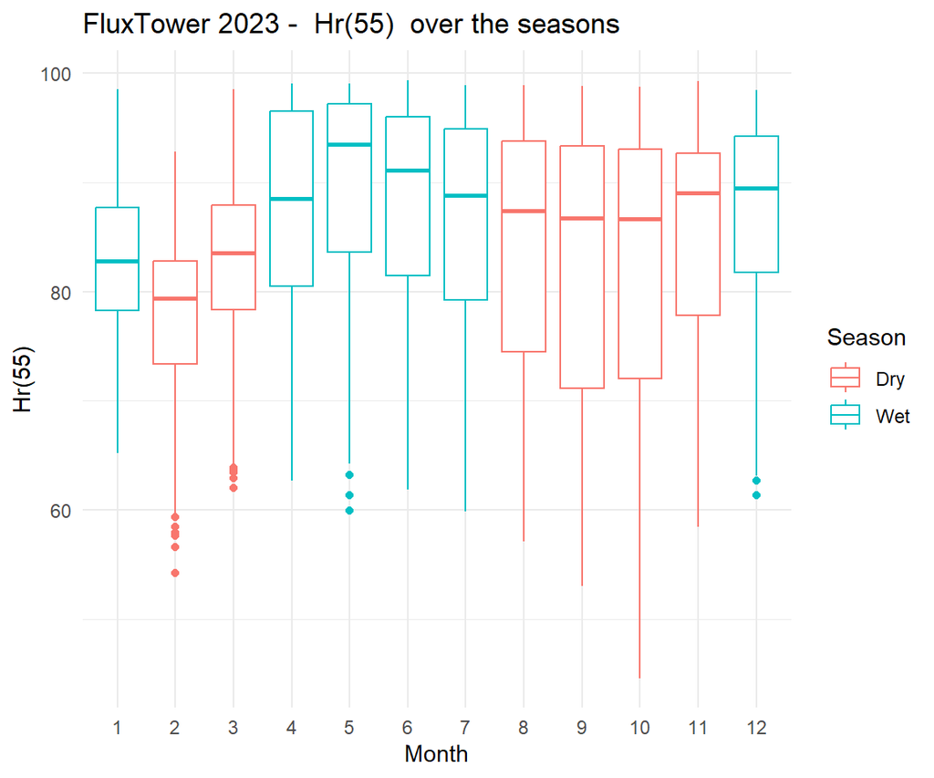

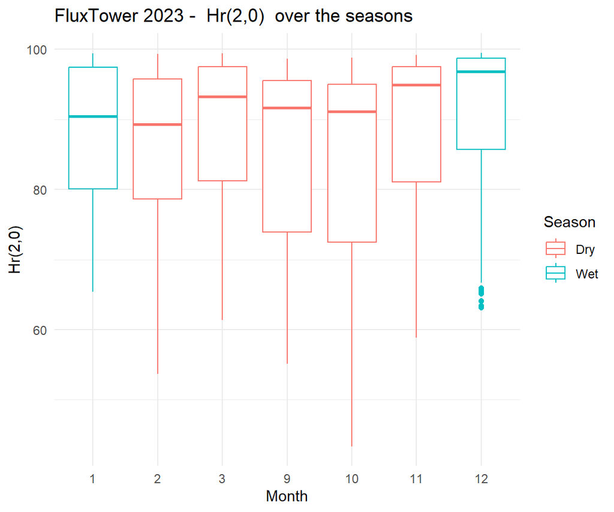

## *Sensor environment data*

## *Sensor data*

### *Data formatting function*

Source: Jérome Chave

Columns :  
- index number of the measure,  
- date and time in UTC,  
- time zone = 4 (French Guiana is UTC-3)  
- T1, T2, T3,  
- soil moisture count,  
- shake = 0  
- errFlag (if =1 the device couldn’t convert time from PCF chip) = NA

### *Format all the files*

```
##  TomstSensorNum        Time_UTC                         TimeZone
##  Length:1951063     Min.   :2021-09-07 15:00:00.00   Min.   :-12.0
##  Class :character   1st Qu.:2022-06-12 14:15:00.00   1st Qu.:  4.0
##  Mode  :character   Median :2023-02-19 18:15:00.00   Median : 92.0
##                     Mean   :2023-02-02 00:23:23.01   Mean   : 66.8
##                     3rd Qu.:2023-09-28 16:00:00.00   3rd Qu.: 92.0
##                     Max.   :2024-05-06 14:30:00.00   Max.   : 92.0
##     SoilTemp        SurfaceTemp       AirTemp           Moisture
##  Min.   :-100.00   Min.   : 0.00   Min.   :-100.00   Min.   :   0
##  1st Qu.:  24.38   1st Qu.:23.75   1st Qu.:  23.12   1st Qu.:1526
##  Median :  25.06   Median :24.75   Median :  24.38   Median :2173
##  Mean   :  23.67   Mean   :24.09   Mean   :  23.50   Mean   :2016
##  3rd Qu.:  25.62   3rd Qu.:25.69   3rd Qu.:  25.75   3rd Qu.:2781
##  Max.   :  40.38   Max.   :39.62   Max.   :  42.00   Max.   :4095
```

# *Combine sensors data and their environment*

## *NA ?*

Check if there are any missing data for T°

## Check if T° <0

# *Manage time information*

Create the different time variables I need and restrict the data to the duration of the study.

```
## [1] TRUE
```

# From raw TDT signal to volumetric moisture content, calibrated from granulometry

Soil moisture sensors need to be calibrated for the soil texture and organic matter concentration that determines the electric conductivity; otherwise the results are uncertain (Bramer et al., 2018).

See Appendix A of the Tomst paper (Wild et al., 2019) for the transformation of the signal into volumetric % moisture from particle size.

*theta=ax^2+bx+c*, where theta is volumetric moisture content and x is raw TDT signal.

data: %clay, silt, sand, bulk density (g/cm3)

```
## [1] 808136
```

## Checks

```
## # A tibble: 4 × 4
##   TopoHabitat             a        b      c
##   <chr>               <dbl>    <dbl>  <dbl>
## 1 Lower slope -0.0000000200 0.000253 -0.157
## 2 Mid slope   -0.0000000222 0.000288 -0.187
## 3 Upper slope -0.0000000224 0.000285 -0.185
## 4 Plateau     -0.0000000232 0.000292 -0.190
```

```
##  [1] "TomstSensorNum"               "Time_UTC"
##  [3] "TimeZone"                     "SoilTemp"
##  [5] "SurfaceTemp"                  "AirTemp"
##  [7] "ElectricMoisture"             "Site"
##  [9] "Plot"                         "SubPlot"
## [11] "HoboID"                       "TomstID"
## [13] "Transect"                     "LightHabitat"
## [15] "TopoHabitat"                  "LayonEdge"
## [17] "TreeNum1"                     "TreeNum2"
## [19] "TreeNum3"                     "DTree1"
## [21] "DTree2"                       "DTree3"
## [23] "Tomst_Material_info_30_03_23" "Tomst_Material_info_16_10_23"
## [25] "HOBO_Material_info_16_10_23"  "Tomst_Material_info_25_03_24"
## [27] "TOMST_Material_info_06_05_24" "HOBO_Material_info_06_05_24"
## [29] "Time"                         "Date"
## [31] "Month"                        "Hour"
## [33] "...1"                         "Argiles"
## [35] "Limons"                       "Sables"
## [37] "Sum_st"                       "BulkDensity"
## [39] "a"                            "b"
## [41] "c"                            "VolumetricMoisture"
```

```
## [1] 0
```

```
## numeric(0)
```

```
## logical(0)
```

```
## [1] "sorti de terre, trou mouillé car sol trop dure, puis replacé"
```

```
## [1] "sorti de terre, trou mouillé car sol trop dure, puis déplacé"
```

```
## [1] "pas de chapeau (pas trouvé)"
```

```
## [1] "semble pas mesurer d’humidité"
```

```
## logical(0)
```

```
## logical(0)
```

```
## logical(0)
```

# **Intercalibration !!** (A FAIRE)

- intercalibration de la T° à partir des données prises sur la période dans le bureau (application de la différence ou ramener tout à la médiane) (avant la date de mise en place (*FieldDate*))
- intercalibration de l’humidité avec données prises aux Nouragues lorsque les capteurs étaient tous plantés au même endroit (2023-02-19 12:00:00 to 2023-02-22 16:45:00)

Intercalibration des tomst avec données bureau seulement sur la T° car le capteur ne mesure l’humidité lorsqu’il est hors sol.

# Data checks

- Maximum values of T° of each day are around midday
- Higher values of T° of each day are for sensors in gaps
- Sensors T° < flux tower T°
- Sensors data follow flux tower data

```
##  [1] "TomstSensorNum"               "Time_UTC"
##  [3] "TimeZone"                     "SoilTemp"
##  [5] "SurfaceTemp"                  "AirTemp"
##  [7] "ElectricMoisture"             "Site"
##  [9] "Plot"                         "SubPlot"
## [11] "HoboID"                       "TomstID"
## [13] "Transect"                     "LightHabitat"
## [15] "TopoHabitat"                  "LayonEdge"
## [17] "TreeNum1"                     "TreeNum2"
## [19] "TreeNum3"                     "DTree1"
## [21] "DTree2"                       "DTree3"
## [23] "Tomst_Material_info_30_03_23" "Tomst_Material_info_16_10_23"
## [25] "HOBO_Material_info_16_10_23"  "Tomst_Material_info_25_03_24"
## [27] "TOMST_Material_info_06_05_24" "HOBO_Material_info_06_05_24"
## [29] "Time"                         "Date"
## [31] "Month"                        "Hour"
## [33] "...1"                         "Argiles"
## [35] "Limons"                       "Sables"
## [37] "Sum_st"                       "BulkDensity"
## [39] "a"                            "b"
## [41] "c"                            "VolumetricMoisture"
```

```
## [1] "00:00:00" "18:30:00"
```

```
## [1] "13:30:00"
```

[output not shown]

[output cut: 67 more lines]

```
## # A tibble: 1 × 45
##   TomstSensorNum Time_UTC            TimeZone SoilTemp SurfaceTemp AirTemp
##            <dbl> <dttm>                 <int>    <dbl>       <dbl>   <dbl>
## 1       94223175 2024-01-19 18:45:00       92     25.4        26.6    30.2
## # ℹ 39 more variables: ElectricMoisture <int>, Site <chr>, Plot <chr>,
## #   SubPlot <dbl>, HoboID <dbl>, TomstID <dbl>, Transect <chr>,
## #   LightHabitat <chr>, TopoHabitat <chr>, LayonEdge <lgl>, TreeNum1 <dbl>,
## #   TreeNum2 <dbl>, TreeNum3 <dbl>, DTree1 <dbl>, DTree2 <dbl>, DTree3 <dbl>,
## #   Tomst_Material_info_30_03_23 <lgl>, Tomst_Material_info_16_10_23 <lgl>,
## #   HOBO_Material_info_16_10_23 <chr>, Tomst_Material_info_25_03_24 <lgl>,
## #   TOMST_Material_info_06_05_24 <chr>, HOBO_Material_info_06_05_24 <chr>, …
```

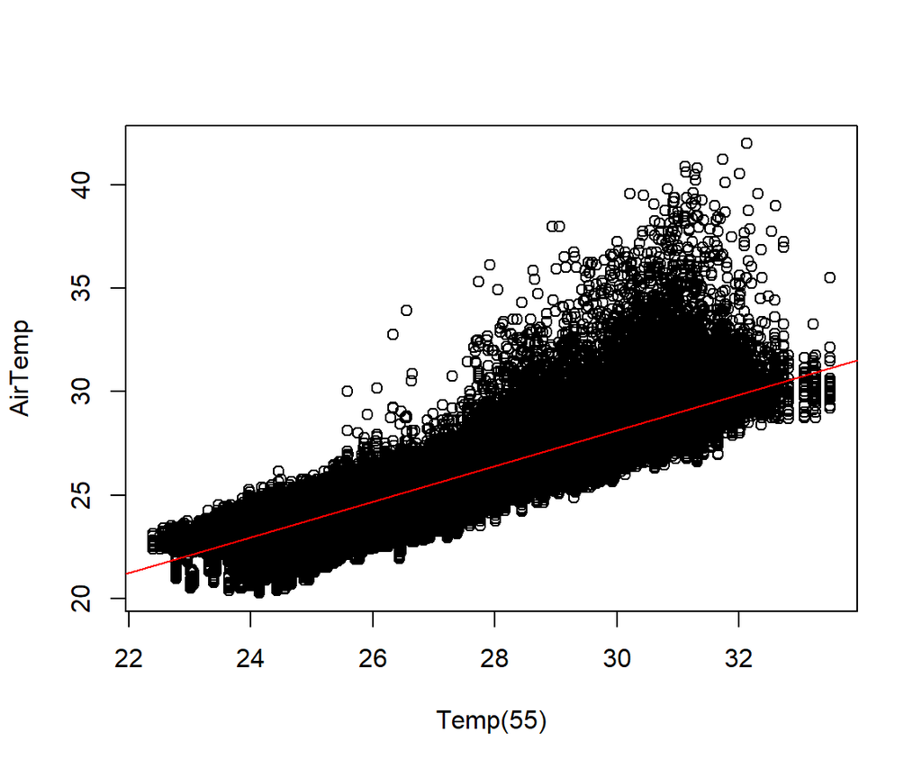

```
## [1] NA
```

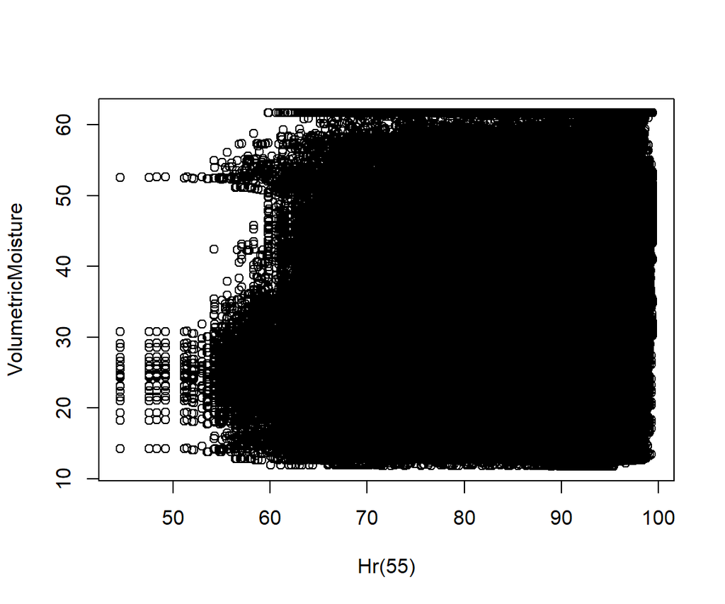

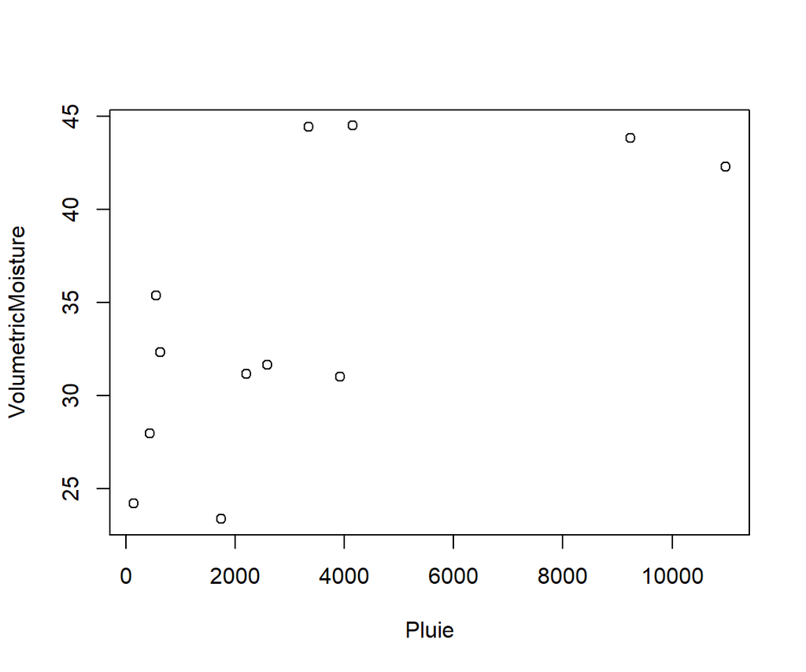

```
## [1] 0.1915793
```

```
## [1] NA NA
```

```
## # A tibble: 427,616 × 59
##    TomstSensorNum Time_UTC            TimeZone SoilTemp SurfaceTemp AirTemp
##             <dbl> <dttm>                 <int>    <dbl>       <dbl>   <dbl>
##  1       94244927 2023-10-22 15:00:00       92     27.5        34.2    35.2
##  2       94244928 2023-09-25 13:00:00       92     26.4        31      34.8
##  3       94223166 2024-03-02 15:30:00       92     25.9        30.9    34.1
##  4       94244927 2023-10-12 15:00:00       92     27.4        35.9    36.6
##  5       94244927 2023-10-18 14:00:00       92     26.6        35      35.4
##  6       94244927 2023-11-23 15:00:00       92     27.8        35.9    35.4
##  7       94244926 2023-08-04 15:30:00       92     26.4        31      34.9
##  8       94244926 2023-10-18 16:00:00       92     27.5        33.8    36.5
##  9       94244926 2023-08-10 15:30:00       92     26.5        30.8    34.6
## 10       94244926 2023-09-09 16:30:00       92     27.8        33.9    35.6
## # ℹ 427,606 more rows
## # ℹ 53 more variables: ElectricMoisture <int>, Site <chr>, Plot <chr>,
## #   SubPlot <dbl>, HoboID <dbl>, TomstID <dbl>, Transect <chr>,
## #   LightHabitat <chr>, TopoHabitat <chr>, LayonEdge <lgl>, TreeNum1 <dbl>,
## #   TreeNum2 <dbl>, TreeNum3 <dbl>, DTree1 <dbl>, DTree2 <dbl>, DTree3 <dbl>,
## #   Tomst_Material_info_30_03_23 <lgl>, Tomst_Material_info_16_10_23 <lgl>,
## #   HOBO_Material_info_16_10_23 <chr>, Tomst_Material_info_25_03_24 <lgl>, …
```

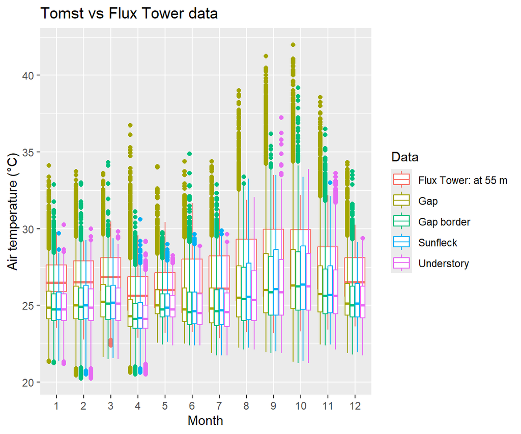

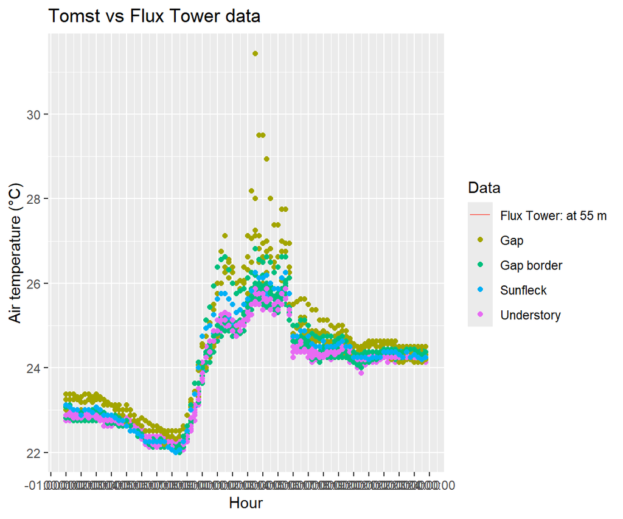

# Plot data of each sensor to check

Make graphs for each sensor to check that they are working.

une ligne d’une couleur pour chaque jour, le temps en abscisse la var clim en ordonnée

## T°

```
## [1] "2023-04-01"
```

## Moisture

```
## [1] "2023-04-01"
```

# Plot relation between VolumetricMoisture and temperatures*

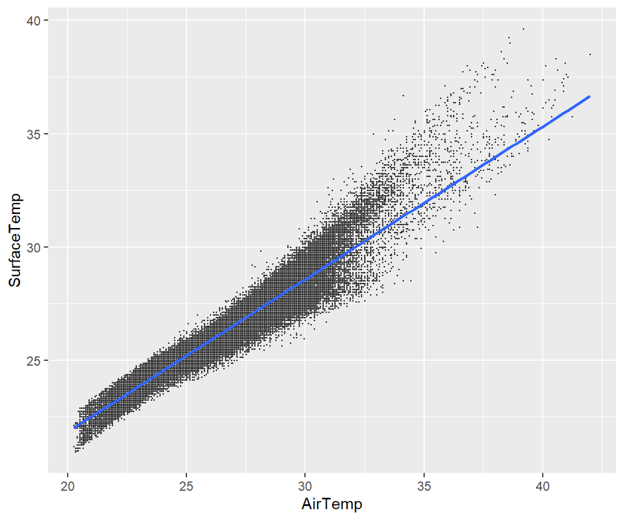

```
## cor: 0.9639982
```

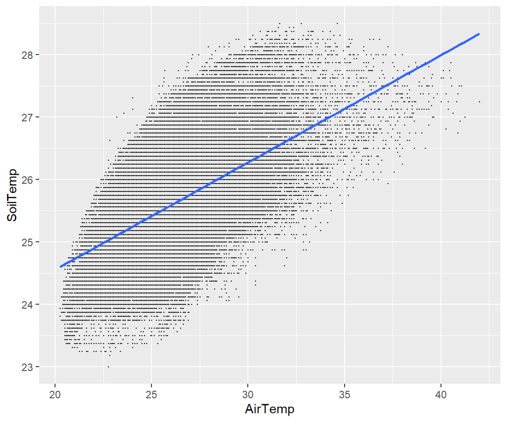

```
## cor: 0.5569284
```

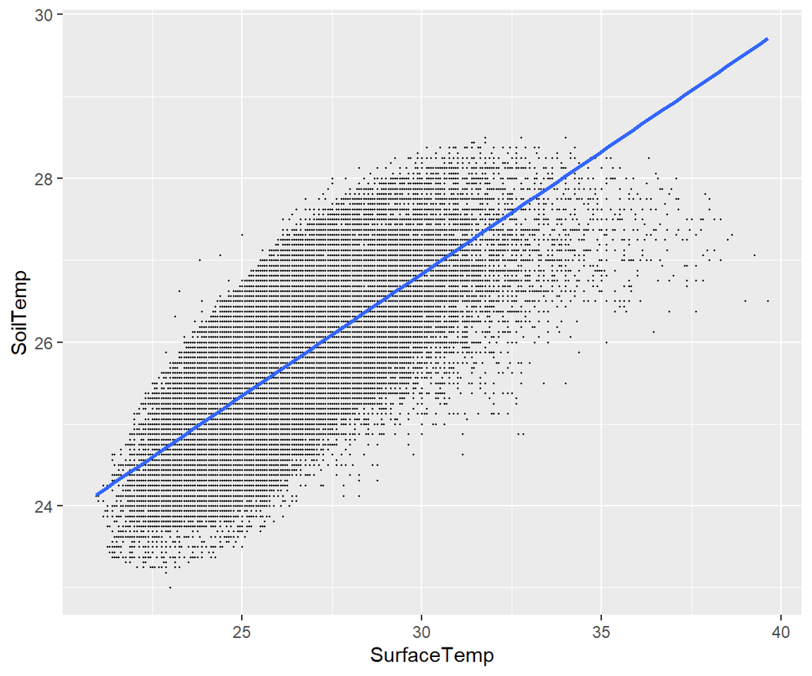

```
## cor: 0.6759535
```

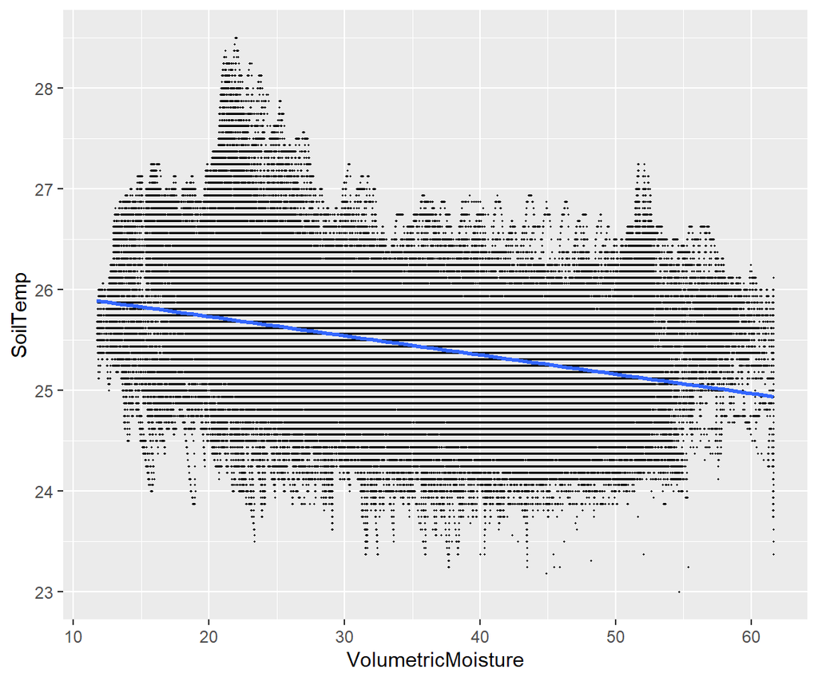

```
## cor: NA
```

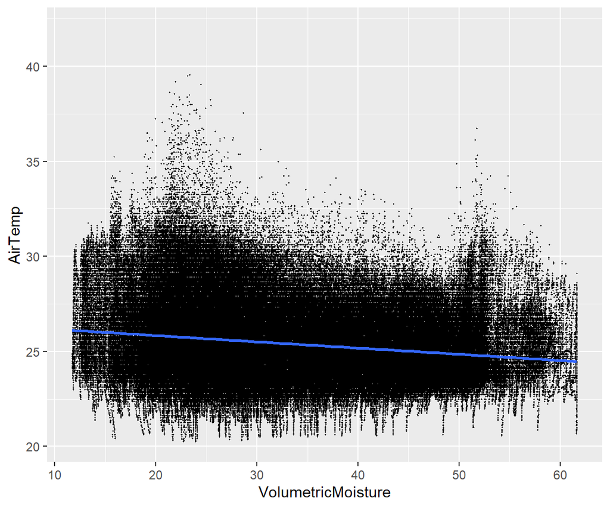

```
## cor: NA
```

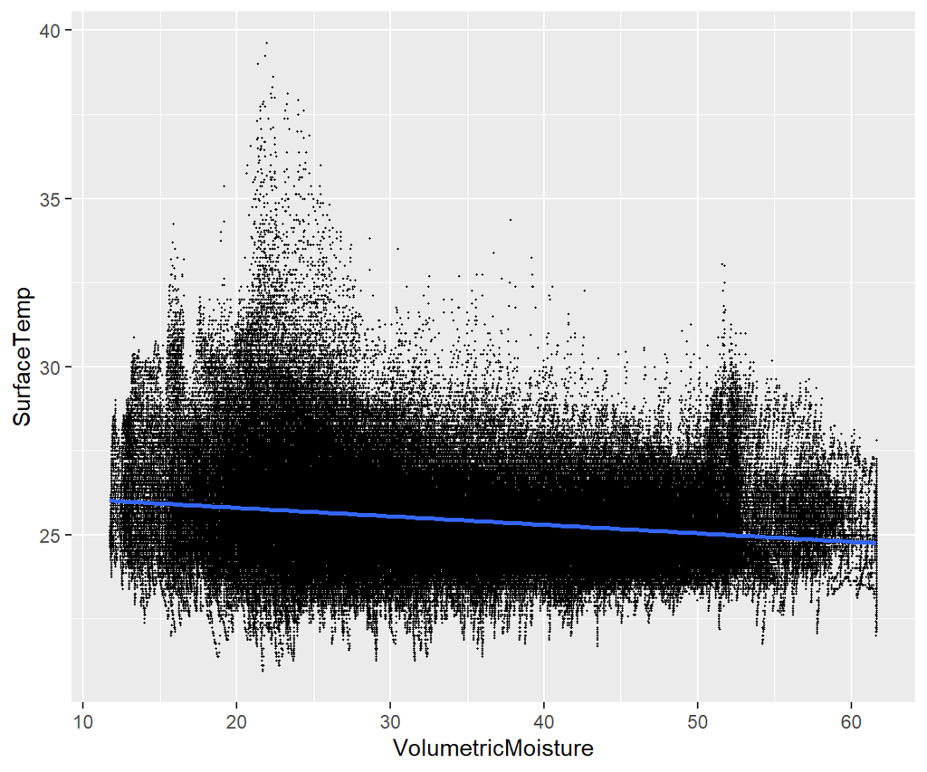

```
## cor: NA
```

*Très bien corrélés : Air et surface temp.*

*Surface et soil temp corrèlent moins bien.*

*Air et soil temp corrèlent encore moins bien. -> la température du sol est tamponnée*

*Pas corrélé du tout : humidité du sol ni electrique ni volumétrique, et les différentes température même pas celle du sol (**pas normal**).*

# *Day/night*

Jour : de 06:15 à 18:45

```
## Night AirTemp range: 20.4375 28 °C
```

```
## Day AirTemp range: 20.25 42 °C
```

## Plot

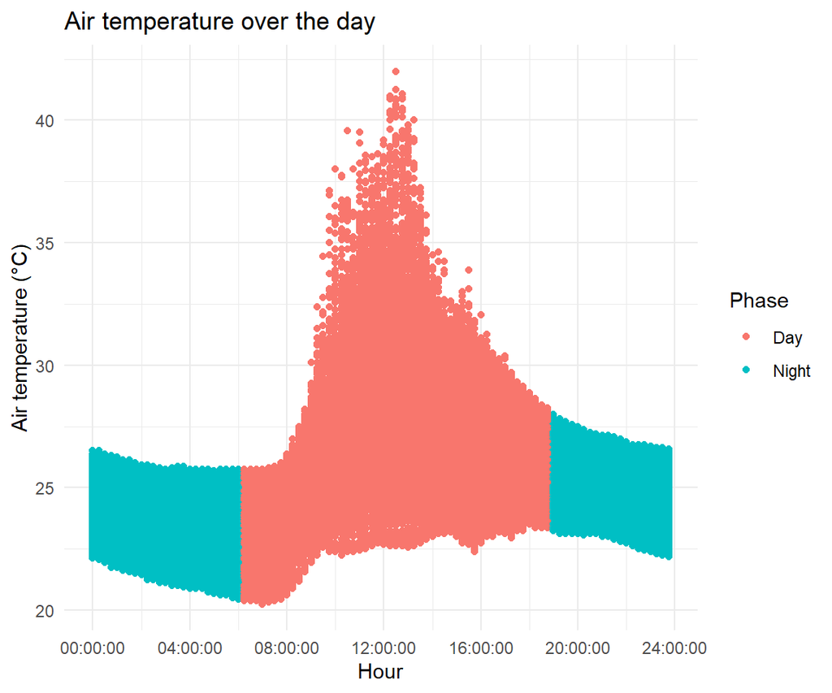

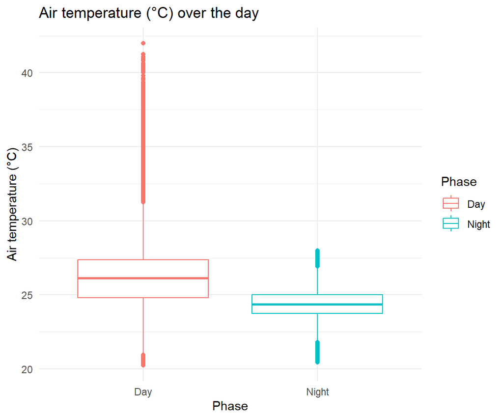

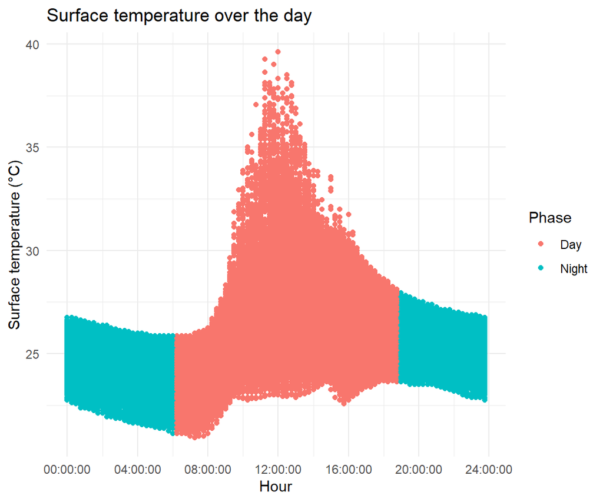

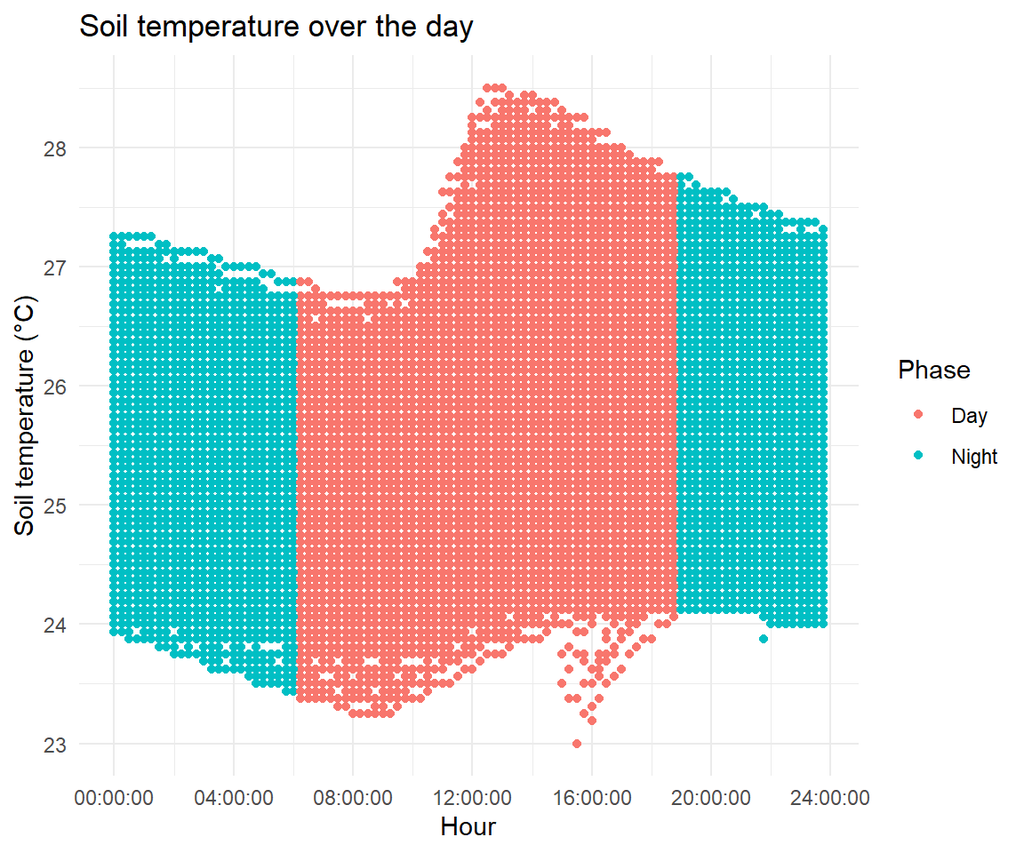

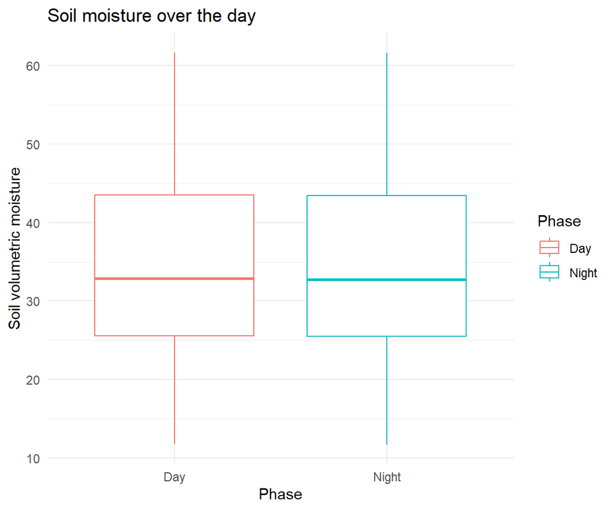

# *Seasons* (à définir à la journée)

Definition of dry season per month : < 100 mm per month (Bonal et al. 2008)

## Plot

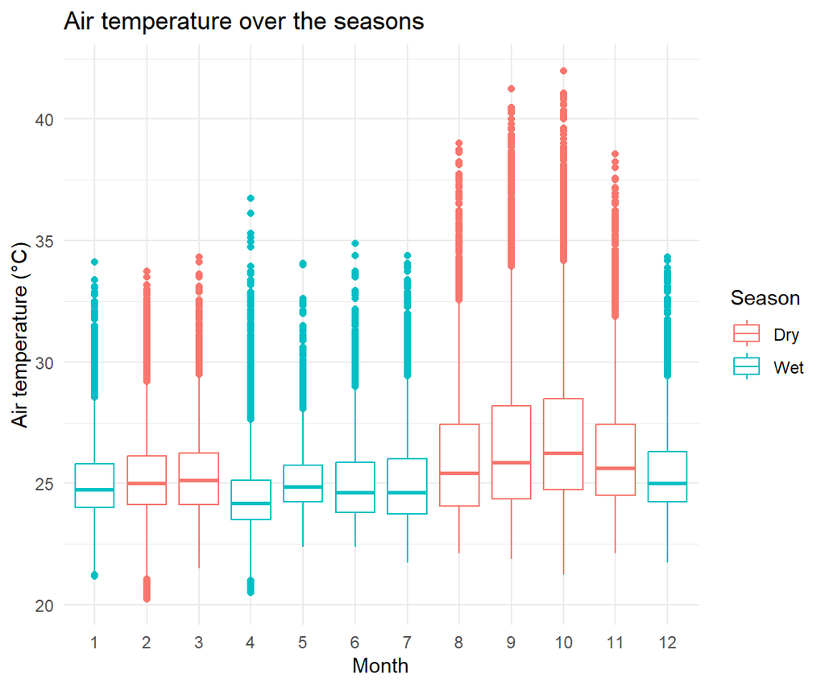

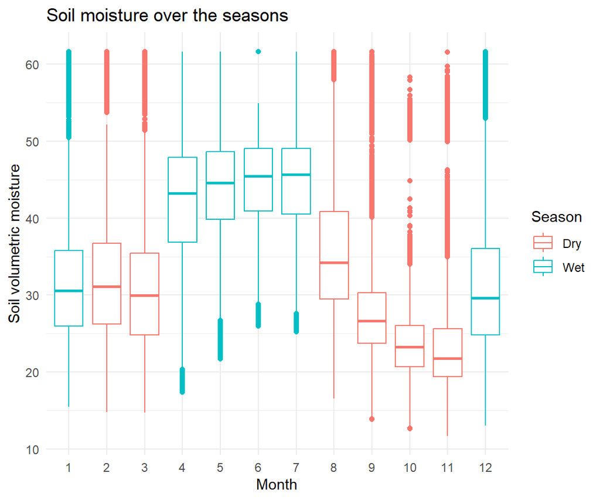

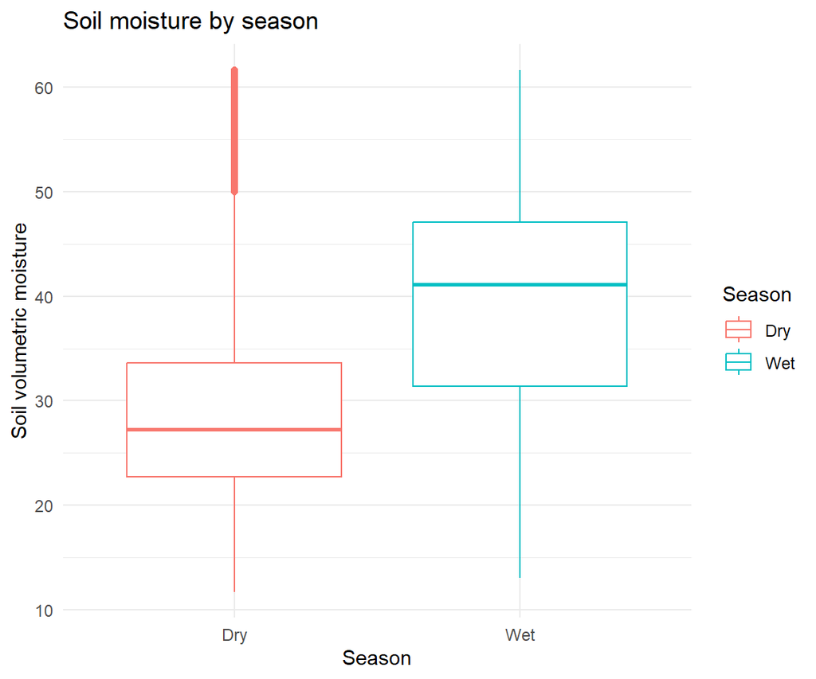

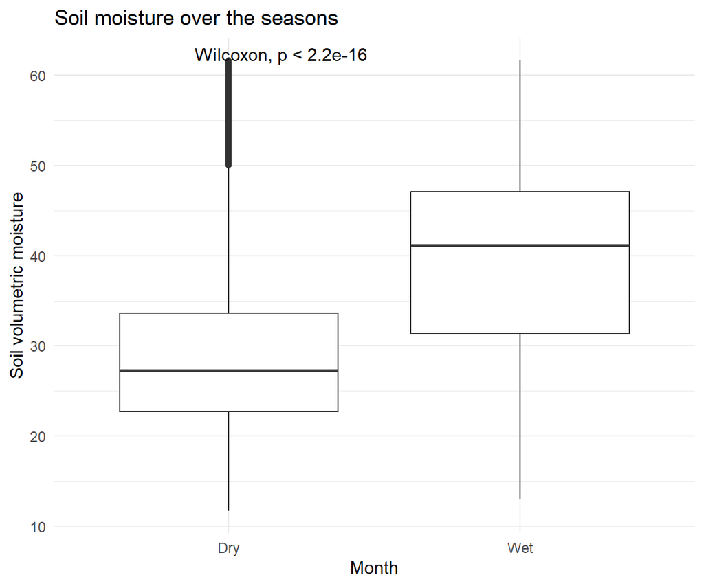

A travers les saisons l’humidité n’est pas incohérente.

# Correlation tests between VolumetricMoisture and season/rain/topography/canopy opening (all values, no means)

pas faire ça mais une comparaison de moyenne pour les variables catégoricielles (Sylvain)

```
##
##  Spearman's rank correlation rho
##
## data:  DF_cor$VolumetricMoisture and DF_cor$Season
## S = 3.9535e+16, p-value < 2.2e-16
## alternative hypothesis: true rho is not equal to 0
## sample estimates:
##       rho
## 0.4864285
```

```
##
##  Pearson's product-moment correlation
##
## data:  DF_cor$VolumetricMoisture and as.numeric(DF_cor$Pluie)
## t = 66.18, df = 376994, p-value < 2.2e-16
## alternative hypothesis: true correlation is not equal to 0
## 95 percent confidence interval:
##  0.1040083 0.1103193
## sample estimates:
##       cor
## 0.1071649
```

```
##
##  Spearman's rank correlation rho
##
## data:  DF_cor$VolumetricMoisture and DF_cor$TopoHabitat
## S = 5.5689e+16, p-value < 2.2e-16
## alternative hypothesis: true rho is not equal to 0
## sample estimates:
##       rho
## 0.2765914
```

```
##
##  Spearman's rank correlation rho
##
## data:  DF_cor$VolumetricMoisture and DF_cor$LightHabitat
## S = 5.9988e+16, p-value < 2.2e-16
## alternative hypothesis: true rho is not equal to 0
## sample estimates:
##       rho
## 0.2207435
```

# *Metrics to compute* (avant Sylvain)

à l’échelle du capteur :  
- moyenne de l’année  
- moyenne diurne  
- moyenne nocturne  
- moyenne saison sèche  
- diurne  
- nocturne  
- moyenne saison des pluies  
- diurne  
- nocturne  
- coefficient variation à ces échelles

A quel moment de la journée on observe les plus grandes différences sur le gradient d’ouverture de canopée et sur le gradient topo ? (Kong et al., 2016)

Idée de Sylvain : regrouper BasFonds-LowerSlope; HigherSlope-Plateau

# *Stats dataset*

# *Some plots to check relations between metrics and topography/canopy opening*

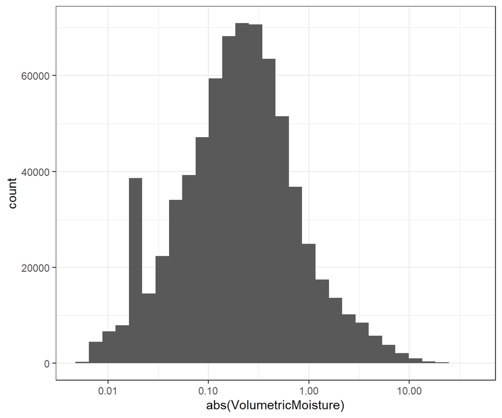

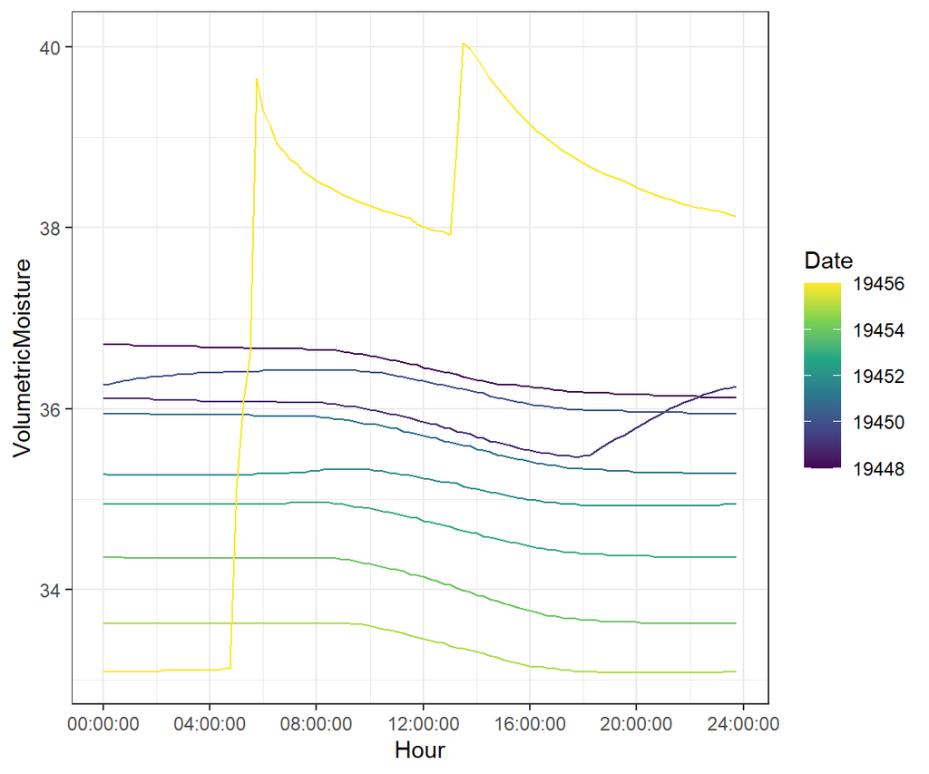

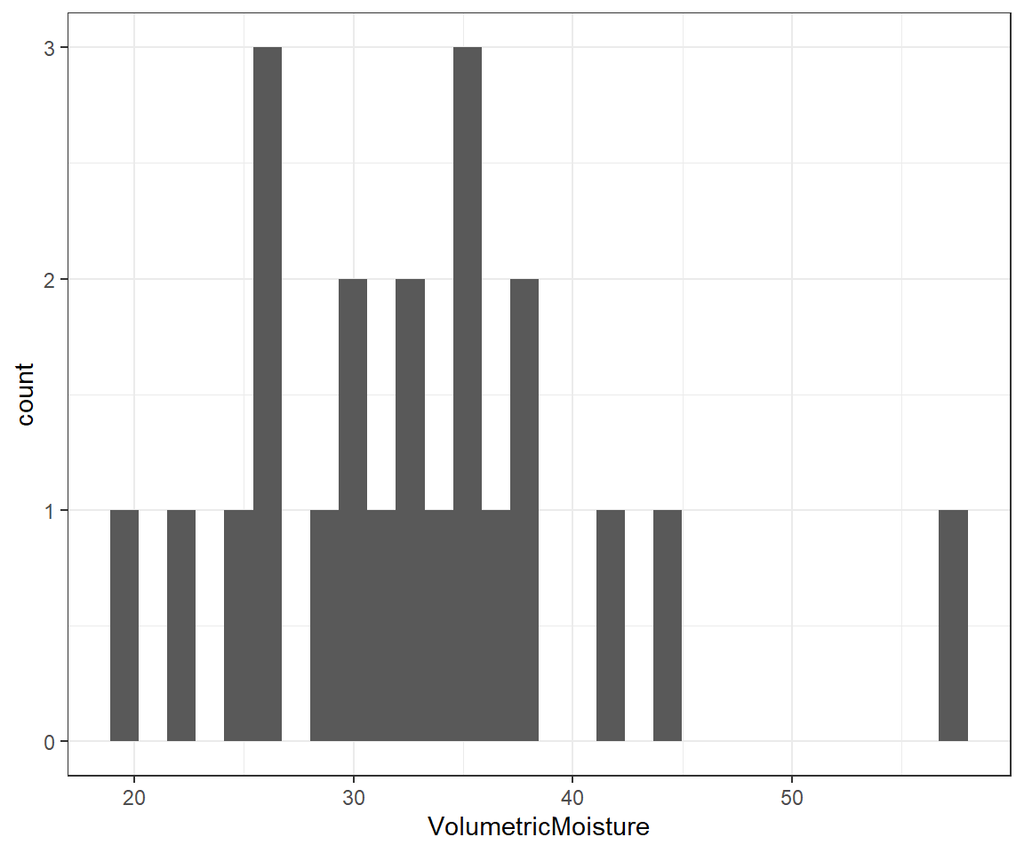

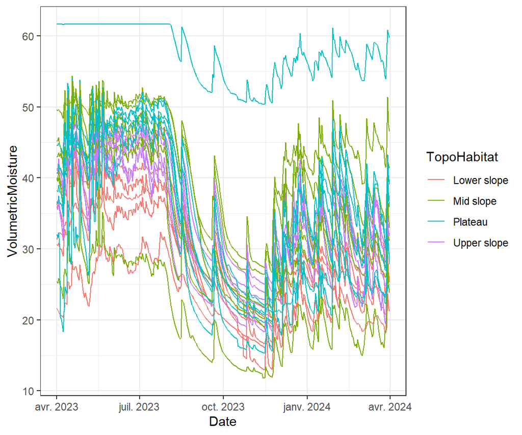

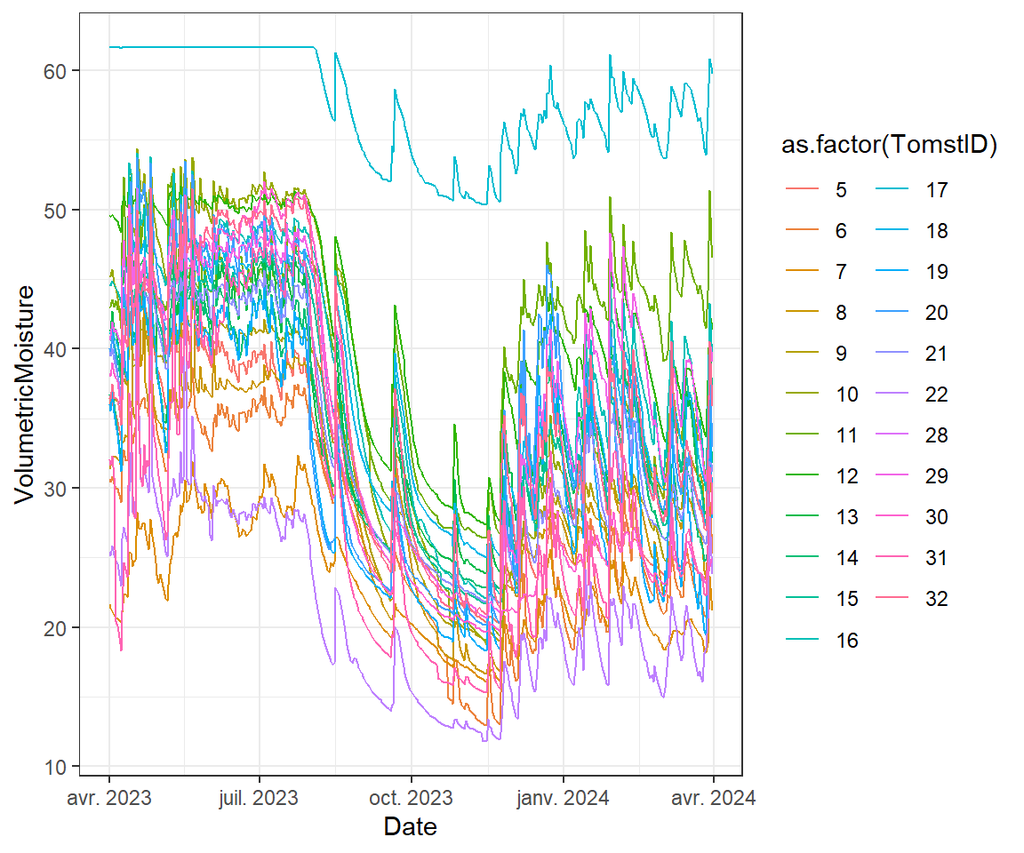

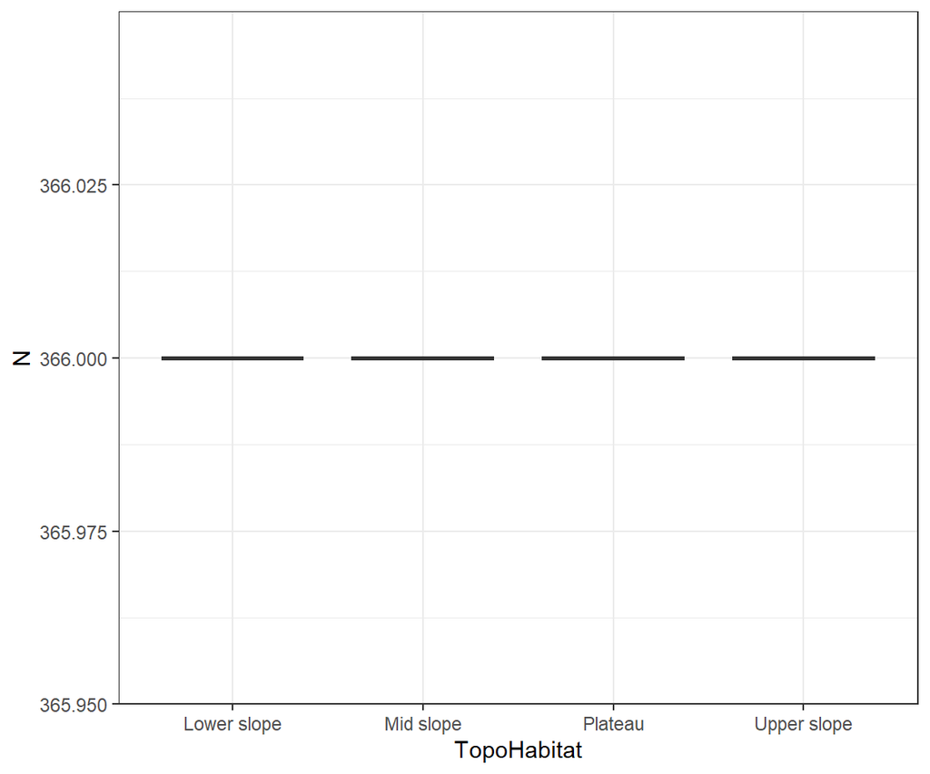

## Relation between soil moisture et sand proportion

calculer la corrélation Moisture - %Sable

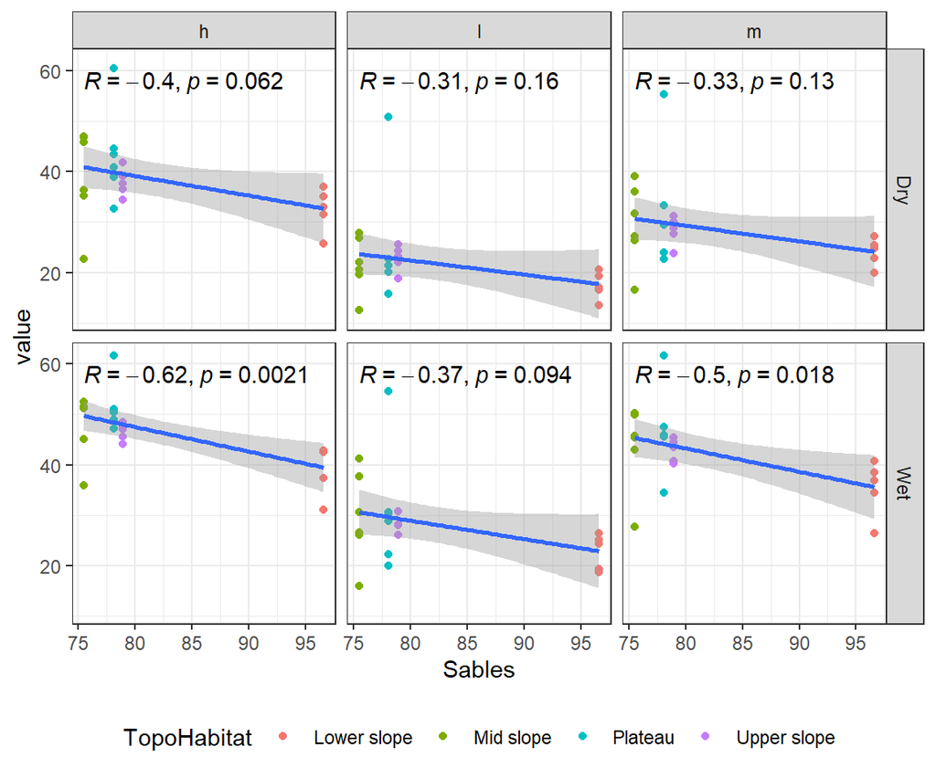

```
## # A tibble: 1 × 1
##   `cor(VolumetricMoisture, Sables)`
##                               <dbl>
## 1                            -0.290
```

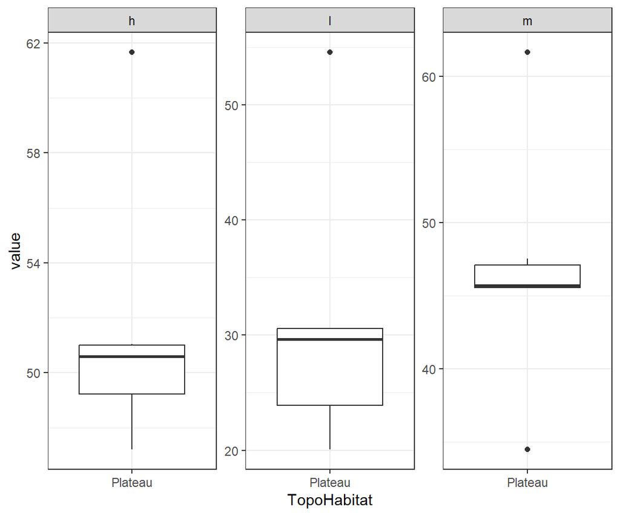

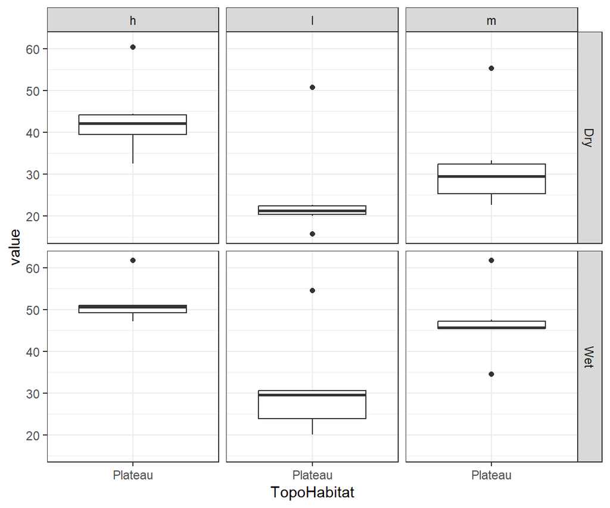

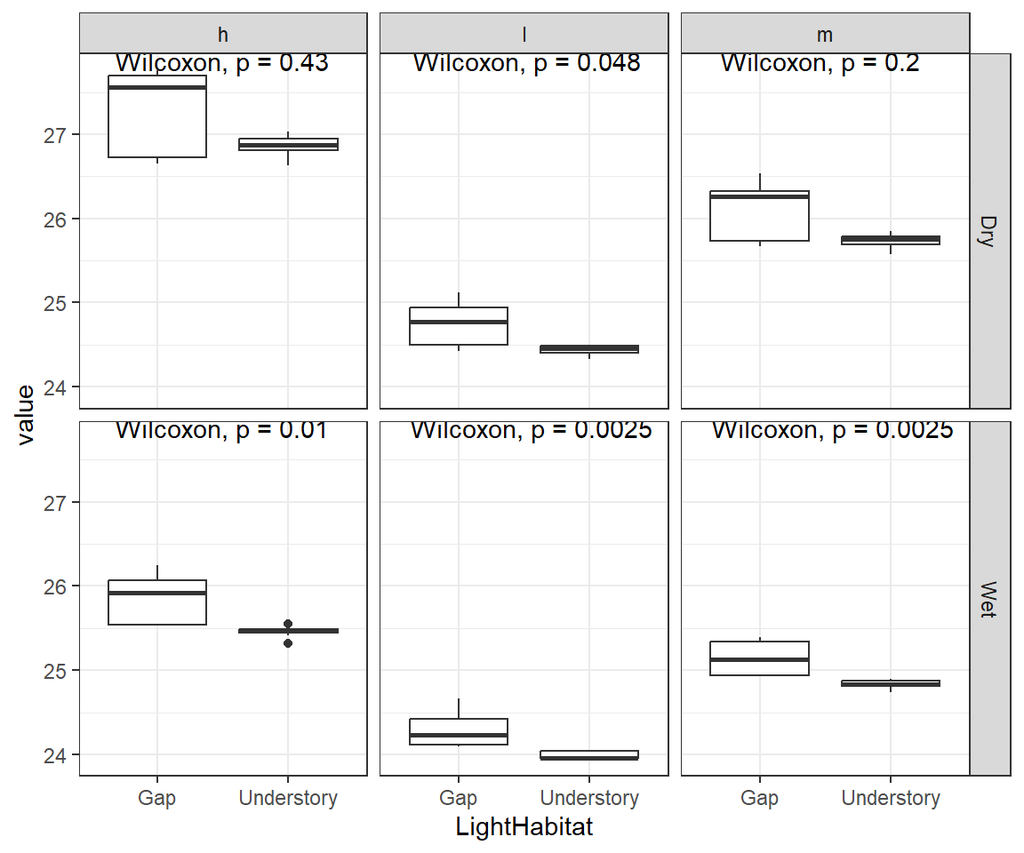

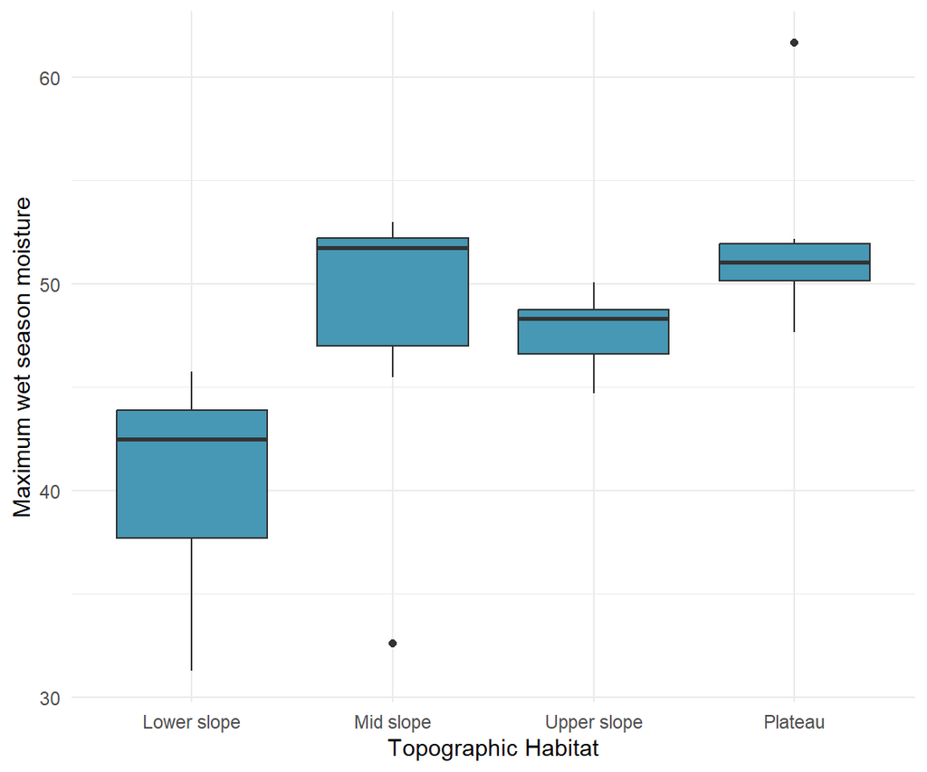

```
## Bizarre. Ya un souci avec l'humidité
```

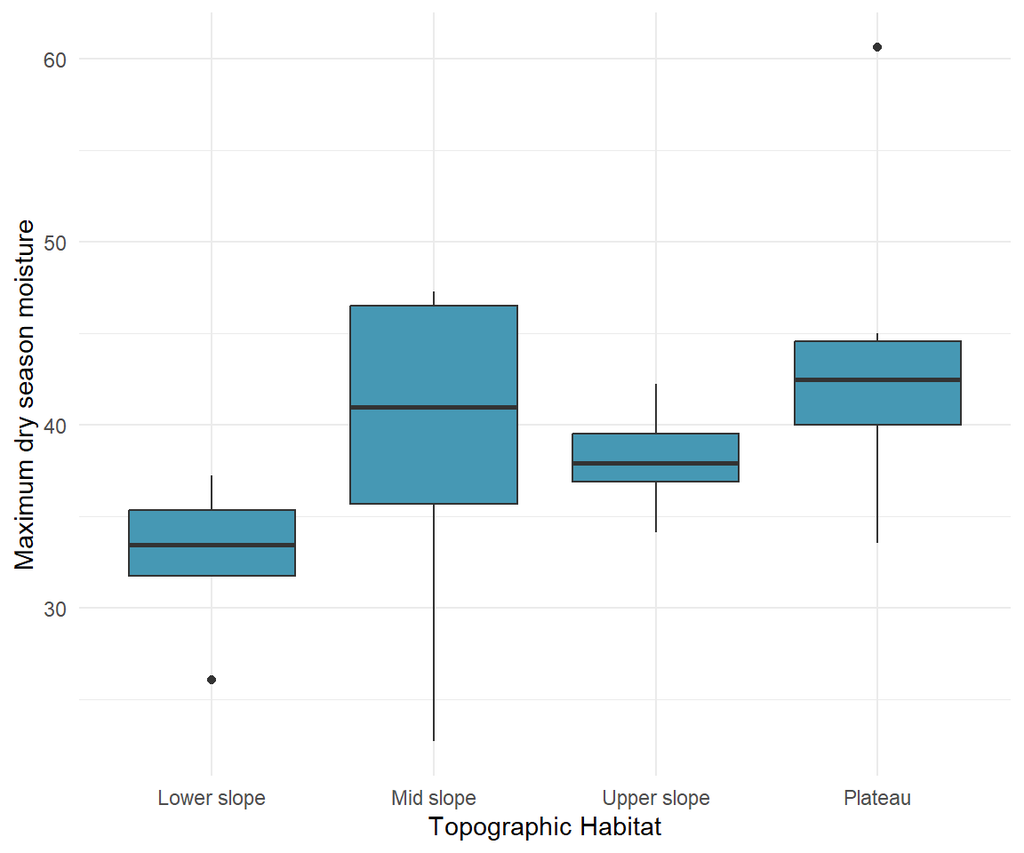

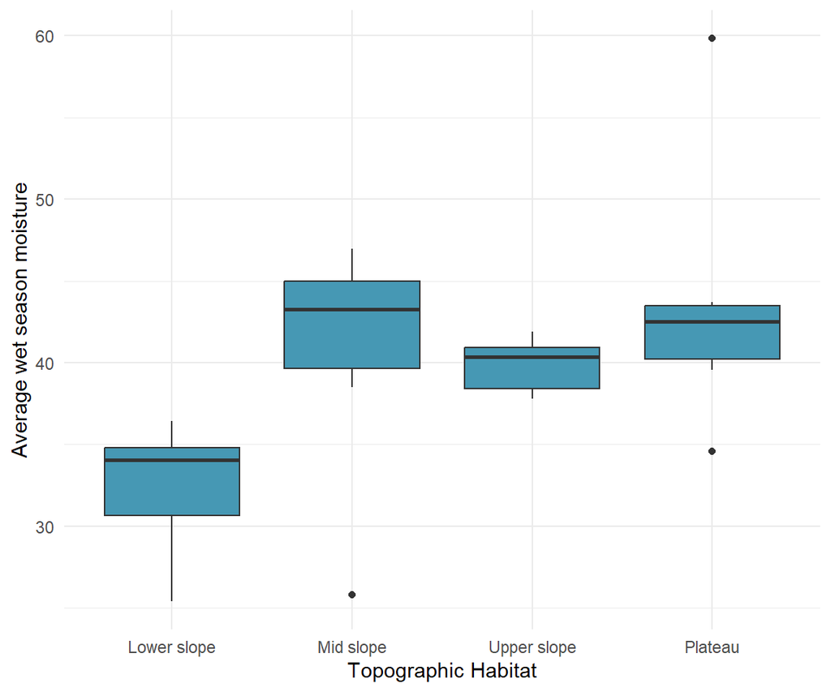

```
## Toujours bizarre
```

[figure not shown]

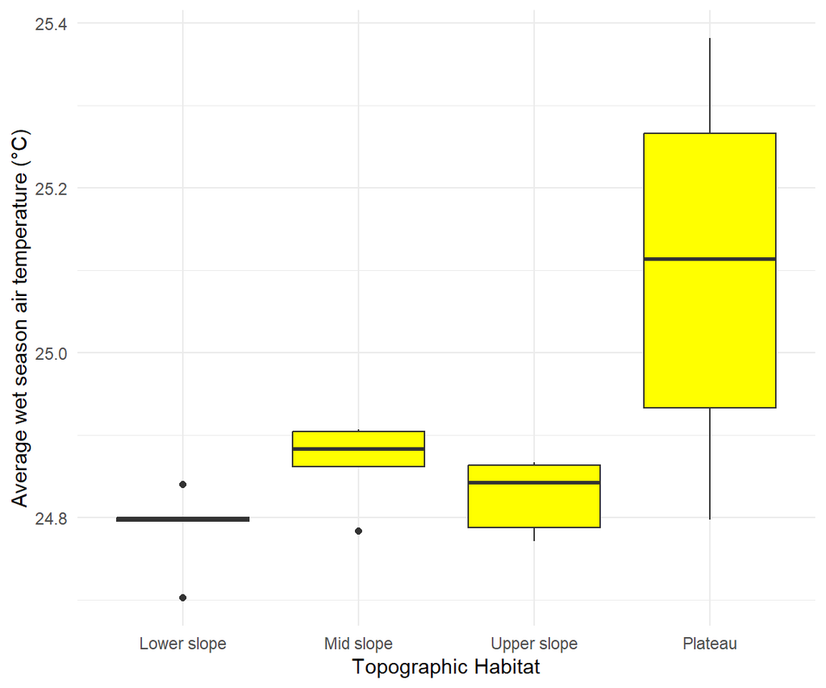

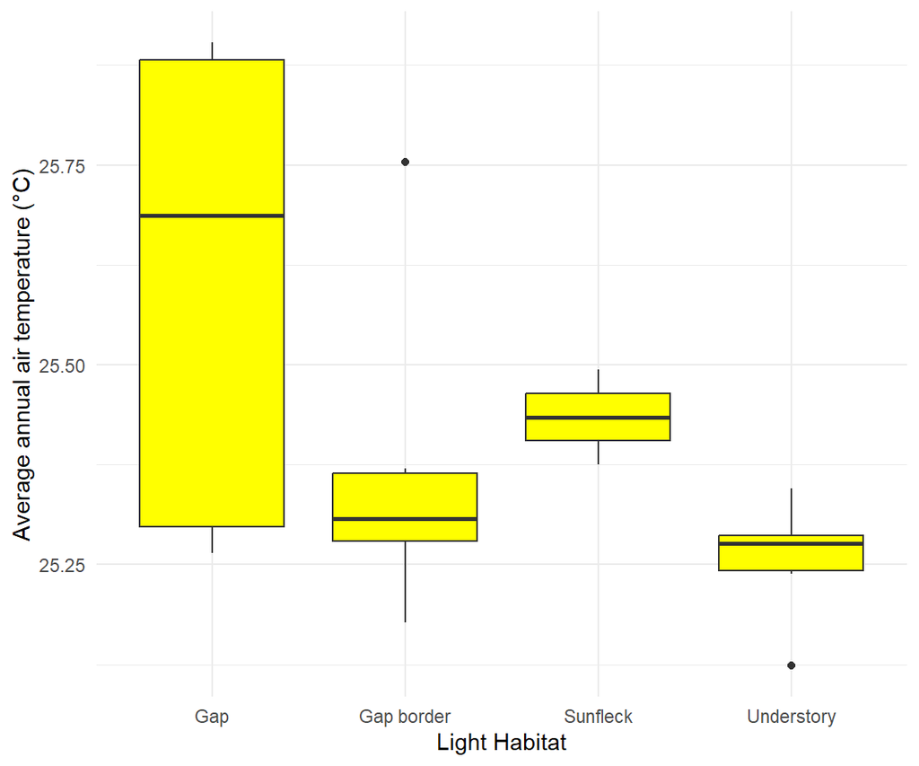

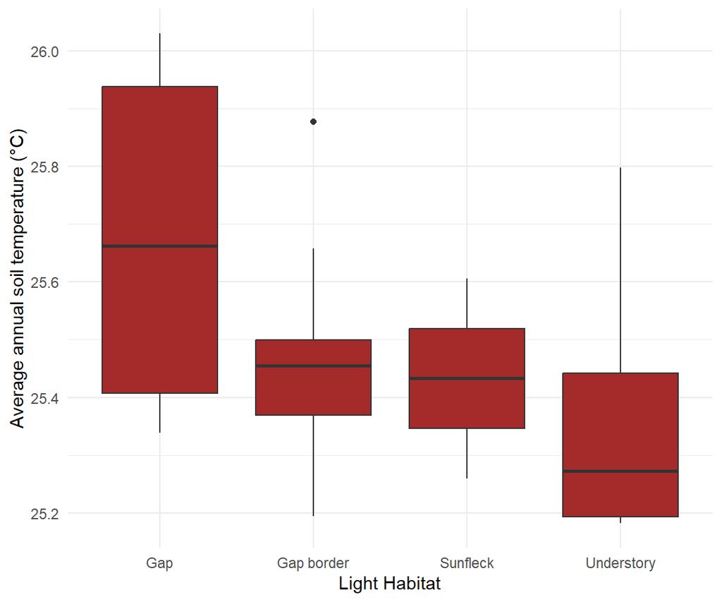

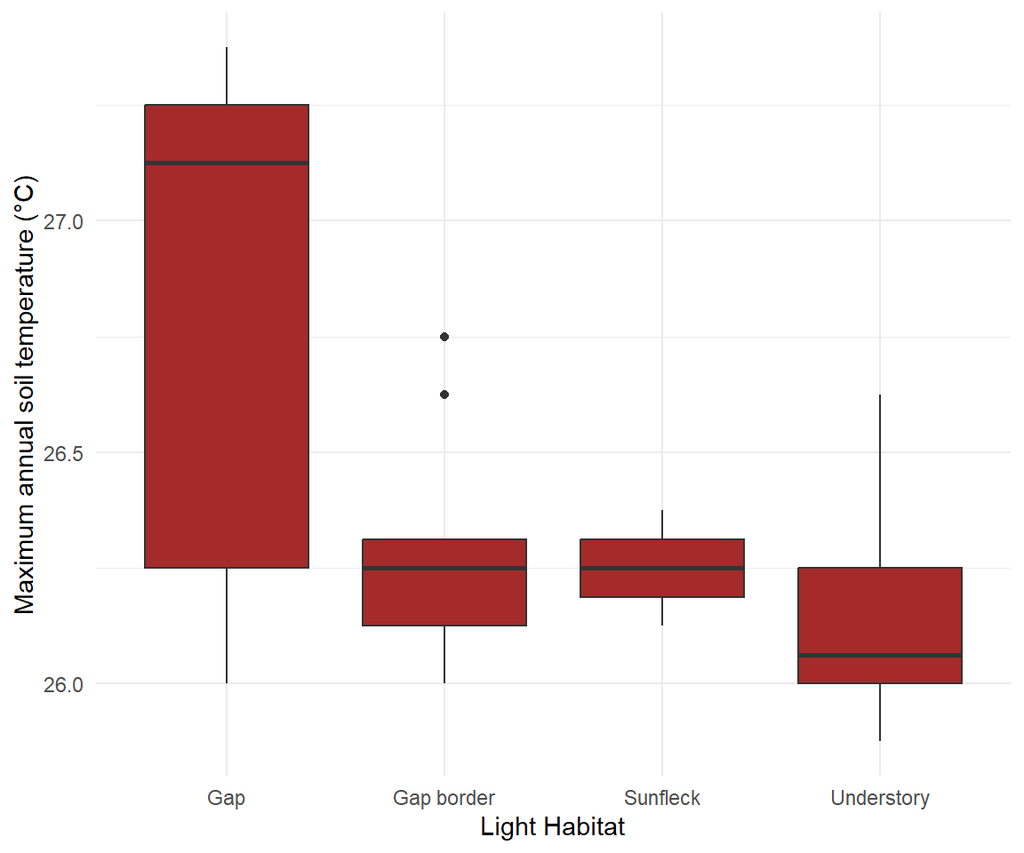

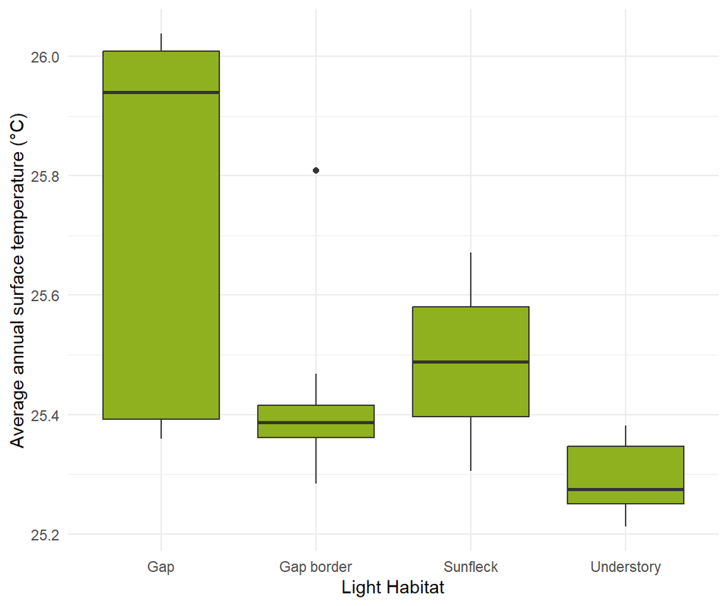

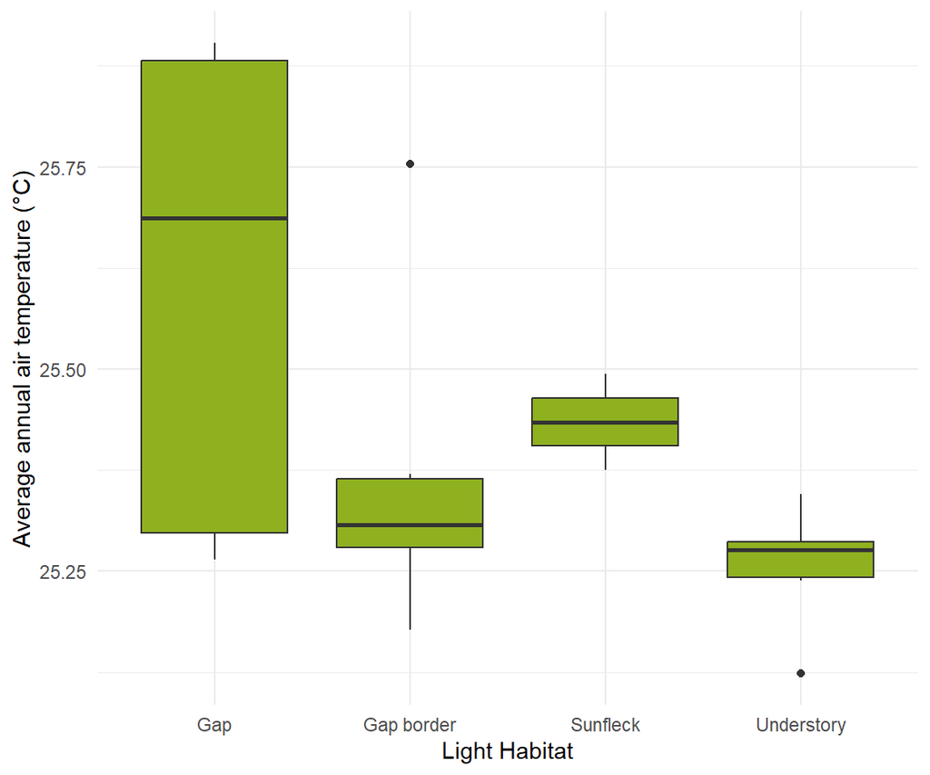

```
## la température à la lumière c'est bon
```

# *Correlation tests between T°/moisture metrics and topography/canopy opening*

Spearman correlation test for categoric variables

[figure not shown]

Strongly linked to LightHabitat:

- *Maximum annual air and surface temperature*
- *Average annual air temperature*
- *Average dry season surface temperature*
- *Maximum wet season air and surface temperature*
- *Average dry and wet season air temperatures*
- *Average day surface and air temperature*
- *Maximum day air and surface temperature*
- *Maximum night surface temperature*

*Linked to TopoHabitat:*

- Maximum night air and surface temperature (+)
- les sd et les varcoef (**je ne sais pas comment les interpréter**)

# Sensors coordinates (mis de côté, à continuer)

## Trilateration

# Save the stats dataset

# References

Maclean, I. M., Duffy, J. P., Haesen, S., Govaert, S., De Frenne, P., Vanneste, T., … & Van Meerbeek, K. (2021). On the measurement of microclimate. Methods in Ecology and Evolution, 12(8), 1397-1410.

Bonal, D., Bosc, A., Ponton, S., GORET, J. Y., Burban, B., Gross, P., … & Granier, A. (2008). Impact of severe dry season on net ecosystem exchange in the Neotropical rainforest of French Guiana. Global Change Biology, 14(8), 1917-1933.

Bramer, I., Anderson, B. J., Bennie, J., Bladon, A. J., De Frenne, P., Hemming, D., … & Gillingham, P. K. (2018). Advances in monitoring and modelling climate at ecologically relevant scales. In Advances in ecological research (Vol. 58, pp. 101-161). Academic Press.

Wild, J., Kopecký, M., Macek, M., Šanda, M., Jankovec, J., & Haase, T. (2019). Climate at ecologically relevant scales: A new temperature and soil moisture logger for long-term microclimate measurement. Agricultural and Forest Meteorology, 268, 40-47.

Kong, F., Yan, W., Zheng, G., Yin, H., Cavan, G., Zhan, W., … & Cheng, L. (2016). Retrieval of three-dimensional tree canopy and shade using terrestrial laser scanning (TLS) data to analyze the cooling effect of vegetation. Agricultural and forest meteorology, 217, 22-34.